# M508D Big Data Analytics - Final Assessment

### Semantic Job Recommendation: End-to-End NLP Project

### By: Md Ather Noor

## 1. Problem Statement

On a job website, people search using their own words. Plain keyword search misses good matches — for example "ML engineer" and "Data Scientist" are similar jobs but use different words. This frustrates candidates and recruiters.

Better matches mean more applications, happier candidates, and faster hiring for the company.

In a real company this would be the website's own job postings and user searches. Here I use a public stand-in: the *1.3M LinkedIn Jobs & Skills* dataset, which has job titles, descriptions, and skills.

As an NLP task, I am do two things:

1. Text classification (supervised): Predict a job's category from its description — this is the trained ML model.
2. Semantic search (ranking): Turn text into vectors and rank jobs by similarity to a search query and returns the most similar jobs.

## 2. High-Level System Design

What each step does and why I need it:

1. Load the data — read the job postings from the CSV files into one table.
2. Clean the text — make everything lowercase and remove links, numbers, and symbols so only useful words remain.
3. TF-IDF — turn the words into numbers, giving each word a score based on how important it is.
4. Train the model — teach a Logistic Regression model to predict a job's category from its text (the machine-learning part).
5. Recommend jobs — for a search query, use cosine similarity to find the jobs with the most similar text.
6. Evaluate — measure how well the model works using accuracy and F1-score

## 3. Import the Libraries

By first importing all python libraries, and then loading the data set

```python
import os, re
import numpy as np
import pandas as pd
import warnings
warnings.filterwarnings("ignore")
from sklearn.feature_extraction.text import TfidfVectorizer
from sklearn.decomposition import TruncatedSVD            # for LSA "meaning vectors"
from sklearn.preprocessing import normalize
from sklearn.model_selection import train_test_split
from sklearn.linear_model import LogisticRegression
from sklearn.metrics import accuracy_score, f1_score, classification_report, confusion_matrix
from sklearn.metrics.pairwise import cosine_similarity
import matplotlib.pyplot as plt
import seaborn as sns
```

## 4. Data Collection

The dataset was obtained from Kaggle and contains LinkedIn job postings, skills, and job summaries.

Three CSV files were merged using the job_link column to create a unified dataset (df) for further preprocessing and recommendation generation.

```python
csv_files = [f for f in os.listdir() if f.endswith('.csv')]
print(csv_files)

jobs = pd.read_csv("linkedin_job_postings.csv")
skills = pd.read_csv("job_skills.csv")
summary = pd.read_csv("job_summary.csv")
print(jobs.shape)
print(skills.shape)
print(summary.shape)
```

```
['job_skills.csv', 'job_summary.csv', 'linkedin_job_postings.csv', 'Raw_View_1_!_Moderat_1765280587345.csv']
(1348454, 14)
(1296381, 2)
(1297332, 2)
```

```python
# Check the columns of the main file
print("JOBS columns:\n", list(jobs.columns), "\n")
jobs.head(3)
```

```
JOBS columns:
 ['job_link', 'last_processed_time', 'got_summary', 'got_ner', 'is_being_worked', 'job_title', 'company', 'job_location', 'first_seen', 'search_city', 'search_country', 'search_position', 'job_level', 'job_type']
```

|  | job_link | last_processed_time | got_summary | got_ner | is_being_worked | job_title | company | job_location | first_seen | search_city | search_country | search_position | job_level | job_type |
| --- | --- | --- | --- | --- | --- | --- | --- | --- | --- | --- | --- | --- | --- | --- |
| 0 | https://www.linkedin.com/jobs/view/account-exe... | 2024-01-21 07:12:29.00256+00 | t | t | f | Account Executive - Dispensing (NorCal/Norther... | BD | San Diego, CA | 2024-01-15 | Coronado | United States | Color Maker | Mid senior | Onsite |
| 1 | https://www.linkedin.com/jobs/view/registered-... | 2024-01-21 07:39:58.88137+00 | t | t | f | Registered Nurse - RN Care Manager | Trinity Health MI | Norton Shores, MI | 2024-01-14 | Grand Haven | United States | Director Nursing Service | Mid senior | Onsite |
| 2 | https://www.linkedin.com/jobs/view/restaurant-... | 2024-01-21 07:40:00.251126+00 | t | t | f | RESTAURANT SUPERVISOR - THE FORKLIFT | Wasatch Adaptive Sports | Sandy, UT | 2024-01-14 | Tooele | United States | Stand-In | Mid senior | Onsite |

```python
# Merge all three on "job_link" into one dataset
df = jobs.merge(summary, on="job_link", how="left")
df = df.merge(skills,  on="job_link", how="left")
print("Merged dataset:", df.shape)
df.head(3)
```

```
Merged dataset: (1348454, 16)
```

|  | job_link | last_processed_time | got_summary | got_ner | is_being_worked | job_title | company | job_location | first_seen | search_city | search_country | search_position | job_level | job_type | job_summary | job_skills |
| --- | --- | --- | --- | --- | --- | --- | --- | --- | --- | --- | --- | --- | --- | --- | --- | --- |
| 0 | https://www.linkedin.com/jobs/view/account-exe... | 2024-01-21 07:12:29.00256+00 | t | t | f | Account Executive - Dispensing (NorCal/Norther... | BD | San Diego, CA | 2024-01-15 | Coronado | United States | Color Maker | Mid senior | Onsite | Responsibilities\nJob Description Summary\nJob... | Medical equipment sales, Key competitors, Term... |
| 1 | https://www.linkedin.com/jobs/view/registered-... | 2024-01-21 07:39:58.88137+00 | t | t | f | Registered Nurse - RN Care Manager | Trinity Health MI | Norton Shores, MI | 2024-01-14 | Grand Haven | United States | Director Nursing Service | Mid senior | Onsite | Employment Type:\nFull time\nShift:\nDescripti... | Nursing, Bachelor of Science in Nursing, Maste... |
| 2 | https://www.linkedin.com/jobs/view/restaurant-... | 2024-01-21 07:40:00.251126+00 | t | t | f | RESTAURANT SUPERVISOR - THE FORKLIFT | Wasatch Adaptive Sports | Sandy, UT | 2024-01-14 | Tooele | United States | Stand-In | Mid senior | Onsite | Job Details\nDescription\nWhat You'll Do\nAs a... | Restaurant Operations Management, Inventory Ma... |

## 5. Data Exploration

These basic exploratory steps included:

- Shape
- Datatypes
- Describes
- Missing values
- Duplicates
- Target balance

### 5a. Column Names and Data Types

I did a basic exploration of the datatypes and some basic statistics of the dataset

```python
print('Shape:', df.shape)
df.dtypes
```

```
Shape: (1348454, 16)
```

```
job_link               object
last_processed_time    object
got_summary            object
got_ner                object
is_being_worked        object
job_title              object
company                object
job_location           object
first_seen             object
search_city            object
search_country         object
search_position        object
job_level              object
job_type               object
job_summary            object
job_skills             object
dtype: object
```

### 5b. Basic Statistics

The .describe() function provides descriptive statistics of all columns in the dataset (including text columns), showing count, unique, top, and freq for each.

```python
df.describe(include="all").T
```

|  | count | unique | top | freq |
| --- | --- | --- | --- | --- |
| job_link | 1348454 | 1348454 | https://www.linkedin.com/jobs/view/account-exe... | 1 |
| last_processed_time | 1348454 | 722748 | 2024-01-19 09:45:09.215838+00 | 625540 |
| got_summary | 1348454 | 2 | t | 1297877 |
| got_ner | 1348454 | 2 | t | 1296401 |
| is_being_worked | 1348454 | 2 | f | 1346978 |
| job_title | 1348454 | 584544 | LEAD SALES ASSOCIATE-FT | 7325 |
| company | 1348443 | 90605 | Health eCareers | 41598 |
| job_location | 1348435 | 29153 | New York, NY | 13436 |
| first_seen | 1348454 | 6 | 2024-01-14 | 460035 |
| search_city | 1348454 | 1018 | Baytown | 10052 |
| search_country | 1348454 | 4 | United States | 1149342 |
| search_position | 1348454 | 1993 | Account Executive | 19468 |
| job_level | 1348454 | 2 | Mid senior | 1204445 |
| job_type | 1348454 | 3 | Onsite | 1337633 |
| job_summary | 1297332 | 958192 | Dollar General Corporation has been delivering... | 4571 |
| job_skills | 1294296 | 1287101 | Front Counter, DriveThru, Outside Order Taker,... | 169 |

### 5c. Missing Values

Then, I checked which columns have missing (NaN) values.

```python
print("Missing values per column:\n", df.isnull().sum())
```

```
Missing values per column:
 job_link                   0
last_processed_time        0
got_summary                0
got_ner                    0
is_being_worked            0
job_title                  0
company                   11
job_location              19
first_seen                 0
search_city                0
search_country             0
search_position            0
job_level                  0
job_type                   0
job_summary            51122
job_skills             54158
dtype: int64
```

### 5d. Duplicate Rows

```python
print("Duplicate job summaries:", df.duplicated(subset=["job_summary"]).sum())
```

```
Duplicate job summaries: 390261
```

### 5e. Target balance

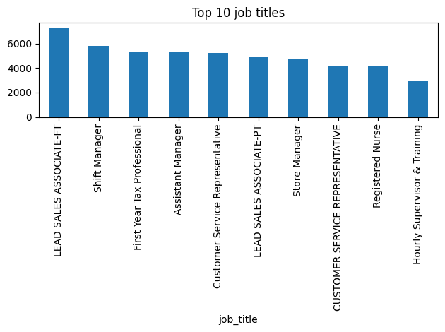

```python
import matplotlib.pyplot as plt
df["job_title"].value_counts().head(10).plot(kind="bar", title="Top 10 job titles")
plt.tight_layout(); plt.show()
```

## 6. Explore the Data (EDA)

keep the 3 columns I need, drop empty/duplicate rows, and use up to 50,000 jobs (for speed)

```python
for c in ["job_title", "job_summary", "job_skills"]:
    if c not in df.columns: df[c] = ""

df = df[["job_title", "job_summary", "job_skills"]].dropna(subset=["job_summary"])
df = df.drop_duplicates(subset=["job_summary"]).reset_index(drop=True)
if len(df) > 50000:
    df = df.sample(50000, random_state=42).reset_index(drop=True)

print("Working with", len(df), "jobs")
df["job_title"].value_counts().head(10)
```

```
Working with 50000 jobs
```

```
job_title
Customer Service Representative                              215
Registered Nurse                                             176
Travel Allied Health Professional - CT Technologist          128
Account Executive                                            114
Senior Accountant                                            112
Executive Assistant                                          107
Store Manager                                                104
Travel Allied Health Professional - Cath Lab Technologist     82
Assistant Manager                                             81
Sous Chef                                                     77
Name: count, dtype: int64
```

## 6a. Make the Category Label

The classifier needs something to predict and turn each job title into a simple **category** using keywords. This becomes our label `y`.

```python
def to_category(title):
    t = str(title).lower()
    if any(w in t for w in ["data scientist", "machine learning", "data analyst", "analytics"]): return "Data & Analytics"
    if any(w in t for w in ["software", "developer", "engineer", "programmer"]):                 return "Software"
    if any(w in t for w in ["nurse", "clinical", "medical", "health", "care"]):                   return "Healthcare"
    if any(w in t for w in ["sales", "account manager", "business development"]):                  return "Sales"
    if any(w in t for w in ["account", "finance", "audit", "tax"]):                               return "Finance"
    if any(w in t for w in ["marketing", "seo", "content", "brand"]):                             return "Marketing"
    return "Other"

df["category"] = df["job_title"].apply(to_category)
df = df[df["category"] != "Other"].reset_index(drop=True)   # keep clean classes
print(df["category"].value_counts())
```

```
category
Healthcare          8222
Software            4152
Finance             1946
Sales               1914
Marketing            328
Data & Analytics     178
Name: count, dtype: int64
```

## 6b. Clean the Text

Uisng a simple cleaner like lowercase, remove links/HTML/numbers/punctuation, keep words only. We join title + description + skills into one `text` column.

```python
def clean_text(t):
    t = str(t).lower()
    t = re.sub(r"http\S+|<.*?>", " ", t)
    t = re.sub(r"[^a-z\s]", " ", t)
    t = re.sub(r"\s+", " ", t).strip()
    return t

df["text"] = (df["job_title"] + " " + df["job_summary"] + " " + df["job_skills"]).apply(clean_text)
df[["job_title", "category", "text"]].head()
```

|  | job_title | category | text |
| --- | --- | --- | --- |
| 0 | Medical Laboratory Scientist - PT / Blood Bank | Healthcare | medical laboratory scientist pt blood bank gen... |
| 1 | Brand Ambassador – Food Sampling | Marketing | brand ambassador food sampling description bra... |
| 2 | Manager of Care Coordination | Healthcare | manager of care coordination overview the mana... |
| 3 | Nurse Practitioner | Healthcare | nurse practitioner the nurse practitioner np f... |
| 4 | Clinical Lab Scientist II, Core Laboratory - E... | Healthcare | clinical lab scientist ii core laboratory even... |

## 7. TF-IDF: Turn Text into Numbers

TF-IDF gives each word a score (high score = important word). This single TF-IDF matrix is used by *both* the classifier and the recommender.

```python
tfidf = TfidfVectorizer(max_features=5000, stop_words="english")
X = tfidf.fit_transform(df["text"])
print("TF-IDF matrix shape (jobs x words):", X.shape)
```

```
TF-IDF matrix shape (jobs x words): (16740, 5000)
```

TF-IDF was picked because it is fast, intuitive, and efficient for text with many keywords. The reason for Logistic Regression being chosen as a classifier is that it is easy to understand, trains quickly from sparse text data and is easy to understand.

For the recommendation system, LSA, which is actually Truncated SVD, takes the sparse TF-IDF data and turns it into 100 dense components representing meaning, which enables jobs having similar wording to cluster together. This makes cosine similarity a good choice because it looks at the vector directions.

## 8. Train the Classifier (the ML model)

Split into train/test, then train a simple **Logistic Regression** to predict the category from the text. I use `class_weight="balanced"` so smaller categories are not ignored.

```python
y = df["category"]
X_train, X_test, y_train, y_test = train_test_split(
    X, y, test_size=0.2, random_state=42, stratify=y)

model = LogisticRegression(max_iter=1000, class_weight="balanced")
model.fit(X_train, y_train)
print("Model trained on", X_train.shape[0], "jobs.")
```

```
Model trained on 13392 jobs.
```

## 9. Evaluate the Classifier

Accuracy alone can be misleading, so also show F1 and a confusion matrix to see each category

```
Accuracy: 0.9561
Weighted F1: 0.9565

Report:
                   precision    recall  f1-score   support

Data & Analytics       0.76      0.94      0.84        36
         Finance       0.93      0.88      0.91       389
      Healthcare       0.99      0.98      0.98      1644
       Marketing       0.79      0.82      0.81        66
           Sales       0.86      0.92      0.89       383
        Software       0.97      0.97      0.97       830

        accuracy                           0.96      3348
       macro avg       0.88      0.92      0.90      3348
    weighted avg       0.96      0.96      0.96      3348
```

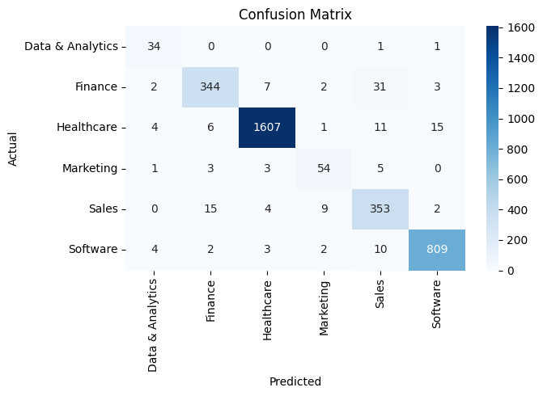

```python
y_pred = model.predict(X_test)
print("Accuracy:", round(accuracy_score(y_test, y_pred), 4))
print("Weighted F1:", round(f1_score(y_test, y_pred, average="weighted"), 4))
print("\nReport:\n", classification_report(y_test, y_pred))

cm = confusion_matrix(y_test, y_pred, labels=model.classes_)
plt.figure(figsize=(7, 5))
sns.heatmap(cm, annot=True, fmt="d", cmap="Blues",
            xticklabels=model.classes_, yticklabels=model.classes_)
plt.xlabel("Predicted"); plt.ylabel("Actual"); plt.title("Confusion Matrix")
plt.tight_layout(); plt.show()
```

The classifier achieved an accuracy of 95.6% and a weighted F1 of 0.957, demonstrating that the model is very reliable at predicting the job categories. In the confusion matrix, Healthcare (1,607 correct) and Software (809 correct) are classified nearly perfectly since there is the highest number of examples in them and they use unique vocabularies.

Data & Analytics and Marketing are weak classes, as they have much less data to learn from.

## 10. Semantic Meaning Vectors (LSA)

The semantic part, TF-IDF only matches exact words. To capture meaning, then I shrink the big TF-IDF matrix into 100 small numbers per job using TruncatedSVD (LSA). Jobs about similar things end up with similar vectors, even if they use different words. Normalise the vectors so I can compare them with cosine similarity.

```python
svd = TruncatedSVD(n_components=100, random_state=42)
emb = normalize(svd.fit_transform(X))     # each job -> 100-number meaning vector
print("Meaning-vector shape:", emb.shape)
print("Information kept:", round(svd.explained_variance_ratio_.sum(), 3))
```

```
Meaning-vector shape: (16740, 100)
Information kept: 0.326
```

## 11. Recommend Similar Jobs

```python
def recommend(query, k=5):
    q = normalize(svd.transform(tfidf.transform([clean_text(query)])))
    sims = cosine_similarity(q, emb)[0]
    top = np.argsort(-sims)[:k]
    out = df.iloc[top][["job_title", "category"]].copy()
    out["score"] = sims[top].round(3)
    return out

recommend("python machine learning and data analysis", k=5)
```

|  | job_title | category | score |
| --- | --- | --- | --- |
| 5492 | Data Scientist (USA) | Data & Analytics | 0.883 |
| 9243 | Data Scientist | Data & Analytics | 0.868 |
| 3276 | AI -Data Scientist Senior (6-10 yrs.) | Data & Analytics | 0.861 |
| 12831 | Senior Data Engineer, New York, Hybrid | Software | 0.850 |
| 3872 | Data Scientist | Data & Analytics | 0.850 |

## 12. Evaluate the Recommender (Ranking Metrics)

Examples look nice, but I should measure quality Then I pick some jobs as test "searches" and say a recommended job is **correct (relevant)** if it has the same category. Also, compute two easy, standard ranking scores:

1. Precision@k — of the top k results, how many are the right category?
2. MAP@k — like precision, but gives more credit when correct jobs are near the top

```python
svd = TruncatedSVD(n_components=100, random_state=42)
emb = svd.fit_transform(X)

# safe normalize (avoids divide-by-zero -> no warnings)
norms = np.linalg.norm(emb, axis=1, keepdims=True)
norms[norms == 0] = 1
emb = emb / norms

print("Meaning-vector shape:", emb.shape)
```

```
Meaning-vector shape: (16740, 100)
```

```python
def evaluate_recommender(n_queries=200, k=5, seed=42):
    rng = np.random.default_rng(seed)
    cats = df["category"].values
    precisions, average_precisions = [], []
    sample = rng.choice(len(df), size=min(n_queries, len(df)), replace=False)
    for qi in sample:
        sims = cosine_similarity(emb[qi:qi+1], emb)[0]
        order = np.argsort(-sims)
        order = order[order != qi][:k]
        hits = [1 if cats[j] == cats[qi] else 0 for j in order]
        precisions.append(np.mean(hits))
        got, ap = 0, 0.0
        for i, h in enumerate(hits):
            if h:
                got += 1
                ap += got / (i + 1)
        average_precisions.append(ap / got if got else 0.0)
    print(f"Precision@{k}: {np.mean(precisions):.4f}")
    print(f"MAP@{k}:       {np.mean(average_precisions):.4f}")
evaluate_recommender()
```

```
Precision@5: 0.9310
MAP@5:       0.9443
```

```python
# a few more example searches
for q in ["hospital nurse patient care", "seo and social media marketing", "tax and audit accountant"]:
    print("Search:", q)
    print(recommend(q, k=3).to_string(index=False))
    print("-" * 60)
```

```
Search: hospital nurse patient care
                                  job_title   category  score
Clinical Nurse II: D4E: Hematology/Oncology Healthcare  0.805
                     Registered Nurse - ICU Healthcare  0.773
Charge Nurse (RN) - PCU at Prime Healthcare Healthcare  0.764
------------------------------------------------------------
Search: seo and social media marketing
                     job_title  category  score
  Digital Marketing Specialist Marketing  0.943
  Digital Marketing Specialist Marketing  0.940
Social Media Marketing Manager Marketing  0.935
------------------------------------------------------------
Search: tax and audit accountant
             job_title category  score
            Accountant  Finance  0.871
Corporate Audit Senior  Finance  0.817
      Accountant Audit  Finance  0.812
------------------------------------------------------------
```

## 13. Summary & Conclusion

#### What I built

A complete NLP pipeline with very simple code: preprocessing, clean text, TF-IDF, a trained Logistic Regression classifier (predicts job category), LSA meaning-vectors, a cosine-similarity recommender, evaluation of both parts.

#### How well it works

The classifier is checked with accuracy and F1, and the recommender with Precision@k and MAP@k — so we measure both components, not just show examples.

#### Strengths

1. Covers the full brief (problem, design, components, model, evaluation, discussion).
2. LSA adds real *semantic* matching, but the code stays short and easy.

#### Limitations

1. LSA still works from words, so it can miss deep meaning and word order.
2. The category label comes from title keywords, which is a simple approximation.
3. Use sample of 50,000 rows for speed rather than using all 1.3M.

#### Future work

1. Use Sentence-Transformer embeddings (e.g. `all-MiniLM-L6-v2`) for stronger meaning.
2. Add more categories and use real user clicks to measure recommendation quality.
3. Use a fast vector index (FAISS) to scale to the full dataset.

## Reference

1. Asaniczka. (2024). 1.3M LinkedIn Jobs & Skills (2024)
2. Data set: Kaggle. https://www.kaggle.com/datasets/asaniczka/1-3m-linkedin-jobs-and-skills-2024